# User Engagement Analysis - Data Analyst @ Showwcase

**By Natnicha Palakawong na ayuthaya**

## Outline:

1. Objective of the proposed research
2. Data exploration and cleanning
3. Correlation between variables
4. How many customers logged into Showwcase platform?
5. How many projects added per day on average?
6. Compare bugs during a session, and amount of sessions each day of the week
7. How often each customer logged into a session during October 2019?
8. When did the longest session duration occur?
9. Do customers normally add their own projects and give either likes or comments?
10. Summary

## Objective of the proposed research

The goal of this project is to provide the product team at Showwcase a better understanding of its users. Analyzing the data gathered for October of 2019, Showwcase will be able to have an increased knowledge of the habits, preferences, and overall manner in which the users engage on this platform. This project will allow the product team to gain insight on how Showwcase is operating for its users and how to strengthen Showwcase’s performance among the tech community.

## Data exploration and cleanning

```python
import pandas as pd
import numpy as np
import seaborn as sns
import matplotlib.pyplot as plt
%matplotlib inline
```

```python
df = pd.read_csv("showwcase_sessions.csv")
df.head()
```

|  | session_id | customer_id | login_date | projects_added | likes_given | comment_given | inactive_status | bug_occured | session_projects_added | session_likes_given | session_comments_given | inactive_duration | bugs_in_session | session_duration |
| --- | --- | --- | --- | --- | --- | --- | --- | --- | --- | --- | --- | --- | --- | --- |
| 0 | 624205.0 | 80746.0 | 10/30/19 | False | True | True | True | False | 0.0 | 24.0 | 3.0 | 1146.0 | 0.0 | 1564.0 |
| 1 | 624241.0 | 24520.0 | 10/30/19 | True | True | True | True | False | 2.0 | 3.0 | 5.0 | 133.0 | 0.0 | 1766.0 |
| 2 | 111002.0 | 32047.0 | 10/30/19 | True | True | True | True | False | 1.0 | 5.0 | 5.0 | 1571.0 | 0.0 | 2230.0 |
| 3 | 545113.0 | 23404.0 | 10/30/19 | True | True | True | False | False | 1.0 | 10.0 | 21.0 | 0.0 | 0.0 | 633.0 |
| 4 | 750269.0 | 40235.0 | 10/30/19 | True | True | False | True | False | 3.0 | 16.0 | 0.0 | 1405.0 | 0.0 | 1679.0 |

```python
print(f"There are {df.shape[0]} rows and {df.shape[1]} columns in this dataset.")
```

```
There are 302 rows and 14 columns in this dataset.
```

Explore columns name

```python
df.columns
```

```
Index(['session_id', 'customer_id', 'login_date', 'projects_added',
       'likes_given', 'comment_given', 'inactive_status', 'bug_occured',
       'session_projects_added', 'session_likes_given',
       'session_comments_given', 'inactive_duration', 'bugs_in_session',
       'session_duration'],
      dtype='object')
```

I added a column of active duration.

```python
df["active_duration"] = df["session_duration"] - df["inactive_duration"]
```

```python
df.head()
```

|  | session_id | customer_id | login_date | projects_added | likes_given | comment_given | inactive_status | bug_occured | session_projects_added | session_likes_given | session_comments_given | inactive_duration | bugs_in_session | session_duration | active_duration |
| --- | --- | --- | --- | --- | --- | --- | --- | --- | --- | --- | --- | --- | --- | --- | --- |
| 0 | 624205.0 | 80746.0 | 10/30/19 | False | True | True | True | False | 0.0 | 24.0 | 3.0 | 1146.0 | 0.0 | 1564.0 | 418.0 |
| 1 | 624241.0 | 24520.0 | 10/30/19 | True | True | True | True | False | 2.0 | 3.0 | 5.0 | 133.0 | 0.0 | 1766.0 | 1633.0 |
| 2 | 111002.0 | 32047.0 | 10/30/19 | True | True | True | True | False | 1.0 | 5.0 | 5.0 | 1571.0 | 0.0 | 2230.0 | 659.0 |
| 3 | 545113.0 | 23404.0 | 10/30/19 | True | True | True | False | False | 1.0 | 10.0 | 21.0 | 0.0 | 0.0 | 633.0 | 633.0 |
| 4 | 750269.0 | 40235.0 | 10/30/19 | True | True | False | True | False | 3.0 | 16.0 | 0.0 | 1405.0 | 0.0 | 1679.0 | 274.0 |

```python
df = df.dropna(axis=0, inplace=False)
```

```python
print(f" After eliminating NaN value, there are {df.shape[0]} rows and {df.shape[1]} columns in this dataset.")
```

```
 After eliminating NaN value, there are 299 rows and 15 columns in this dataset.
```

Convert ‘False’ to 0 and ‘True’ to 1

```python
df = df * 1
df.head()
```

|  | session_id | customer_id | login_date | projects_added | likes_given | comment_given | inactive_status | bug_occured | session_projects_added | session_likes_given | session_comments_given | inactive_duration | bugs_in_session | session_duration | active_duration |
| --- | --- | --- | --- | --- | --- | --- | --- | --- | --- | --- | --- | --- | --- | --- | --- |
| 0 | 624205.0 | 80746.0 | 10/30/19 | 0 | 1 | 1 | 1 | 0 | 0.0 | 24.0 | 3.0 | 1146.0 | 0.0 | 1564.0 | 418.0 |
| 1 | 624241.0 | 24520.0 | 10/30/19 | 1 | 1 | 1 | 1 | 0 | 2.0 | 3.0 | 5.0 | 133.0 | 0.0 | 1766.0 | 1633.0 |
| 2 | 111002.0 | 32047.0 | 10/30/19 | 1 | 1 | 1 | 1 | 0 | 1.0 | 5.0 | 5.0 | 1571.0 | 0.0 | 2230.0 | 659.0 |
| 3 | 545113.0 | 23404.0 | 10/30/19 | 1 | 1 | 1 | 0 | 0 | 1.0 | 10.0 | 21.0 | 0.0 | 0.0 | 633.0 | 633.0 |
| 4 | 750269.0 | 40235.0 | 10/30/19 | 1 | 1 | 0 | 1 | 0 | 3.0 | 16.0 | 0.0 | 1405.0 | 0.0 | 1679.0 | 274.0 |

```python
df.info()
```

```
<class 'pandas.core.frame.DataFrame'>
Int64Index: 299 entries, 0 to 299
Data columns (total 15 columns):
session_id                299 non-null float64
customer_id               299 non-null float64
login_date                299 non-null object
projects_added            299 non-null object
likes_given               299 non-null object
comment_given             299 non-null object
inactive_status           299 non-null object
bug_occured               299 non-null object
session_projects_added    299 non-null float64
session_likes_given       299 non-null float64
session_comments_given    299 non-null float64
inactive_duration         299 non-null float64
bugs_in_session           299 non-null float64
session_duration          299 non-null float64
active_duration           299 non-null float64
dtypes: float64(9), object(6)
memory usage: 37.4+ KB
```

Convert the 'login_date' column to datetime format

```python
df['login_date']= pd.to_datetime(df['login_date'])
```

```python
df.info()
```

```
<class 'pandas.core.frame.DataFrame'>
Int64Index: 299 entries, 0 to 299
Data columns (total 15 columns):
session_id                299 non-null float64
customer_id               299 non-null float64
login_date                299 non-null datetime64[ns]
projects_added            299 non-null object
likes_given               299 non-null object
comment_given             299 non-null object
inactive_status           299 non-null object
bug_occured               299 non-null object
session_projects_added    299 non-null float64
session_likes_given       299 non-null float64
session_comments_given    299 non-null float64
inactive_duration         299 non-null float64
bugs_in_session           299 non-null float64
session_duration          299 non-null float64
active_duration           299 non-null float64
dtypes: datetime64[ns](1), float64(9), object(5)
memory usage: 37.4+ KB
```

## Correlation between variables

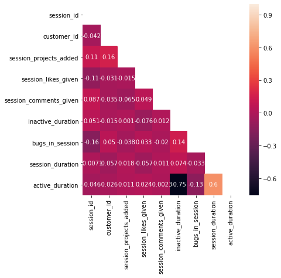

```python
corr = df.corr()
#corr.style.background_gradient(cmap='coolwarm').set_precision(2)
fig, ax = plt.subplots(figsize=(6, 6))
mask = np.zeros_like(corr)
mask[np.triu_indices_from(mask)] = 1
sns.heatmap(corr, mask= mask, ax= ax, annot= True)
```

The plot above shows the relationship between the independent variables. The differing colors represent the relationship between the variables. The darker the color gets, the more negative the linear relationship between the variables is.

## How many customers logged into Showwcase platform?

```python
print(f"There are {len(df.customer_id.unique())} customers who logged into Showwcase in October, 2019")
```

```
There are 48 customers who logged into Showwcase in October, 2019
```

## How many projects added per day on average?

```python
df_n = df["session_projects_added"].groupby(df.login_date).sum().reset_index(name="n_projects").sort_values(by='login_date')
df_n_bugs = df["bugs_in_session"].groupby(df.login_date).sum().reset_index(name='n_bugs').sort_values(by='login_date')
df_n_sessions = df["session_id"].groupby(df.login_date).count().reset_index(name='n_sessions').sort_values(by='login_date')
df_duration = df["active_duration"].groupby(df.login_date).mean().reset_index(name='avg_duration').sort_values(by='login_date')
df_n_comments = df["session_comments_given"].groupby(df.login_date).sum().reset_index(name='n_comments').sort_values(by='login_date')
df_n_likes = df["session_likes_given"].groupby(df.login_date).sum().reset_index(name='n_likes').sort_values(by='login_date')
```

```python
df_n.insert(2, "n_bugs", df_n_bugs.n_bugs, True)
df_n.insert(3, "n_sessions", df_n_sessions.n_sessions, True)
df_n.insert(4, "avg_duration", df_duration.avg_duration, True)
df_n.insert(5, "n_comments", df_n_comments.n_comments, True)
df_n.insert(6, "n_likes", df_n_likes.n_likes, True)
```

```python
df_n.head()
```

|  | login_date | n_projects | n_bugs | n_sessions | avg_duration | n_comments | n_likes |
| --- | --- | --- | --- | --- | --- | --- | --- |
| 0 | 2019-10-01 | 16.0 | 0.0 | 9 | 795.444444 | 5.0 | 13.0 |
| 1 | 2019-10-02 | 12.0 | 2.0 | 5 | 24.800000 | 6.0 | 20.0 |
| 2 | 2019-10-03 | 19.0 | 20.0 | 10 | 551.800000 | 18.0 | 88.0 |
| 3 | 2019-10-04 | 8.0 | 2.0 | 9 | 370.777778 | 23.0 | 129.0 |
| 4 | 2019-10-05 | 22.0 | 7.0 | 14 | 962.857143 | 23.0 | 234.0 |

Make the login date the indicies

```python
df_n = df_n.set_index('login_date')
df_n['dayofweek'] = df_n.index.dayofweek
df_n.head()
```

| login_date | n_projects | n_bugs | n_sessions | avg_duration | n_comments | n_likes | dayofweek |
| --- | --- | --- | --- | --- | --- | --- | --- |
| 2019-10-01 | 16.0 | 0.0 | 9 | 795.444444 | 5.0 | 13.0 | 1 |
| 2019-10-02 | 12.0 | 2.0 | 5 | 24.800000 | 6.0 | 20.0 | 2 |
| 2019-10-03 | 19.0 | 20.0 | 10 | 551.800000 | 18.0 | 88.0 | 3 |
| 2019-10-04 | 8.0 | 2.0 | 9 | 370.777778 | 23.0 | 129.0 | 4 |
| 2019-10-05 | 22.0 | 7.0 | 14 | 962.857143 | 23.0 | 234.0 | 5 |

```python
df_day = df_n.pivot_table(index='dayofweek', aggfunc='mean')
df_day
```

| dayofweek | avg_duration | n_bugs | n_comments | n_likes | n_projects | n_sessions |
| --- | --- | --- | --- | --- | --- | --- |
| 0 | 469.803205 | 10.25 | 25.00 | 123.75 | 15.25 | 10.25 |
| 1 | 352.054149 | 11.60 | 19.60 | 88.00 | 15.40 | 9.80 |
| 2 | 503.295556 | 7.00 | 18.20 | 56.80 | 13.60 | 6.40 |
| 3 | 419.538690 | 13.00 | 27.75 | 81.00 | 17.25 | 10.25 |
| 4 | 543.551587 | 4.75 | 22.25 | 115.50 | 13.75 | 10.00 |
| 5 | 560.351326 | 18.75 | 30.50 | 163.50 | 22.00 | 13.50 |
| 6 | 333.023539 | 22.50 | 27.25 | 117.00 | 16.50 | 10.50 |

```python
df_day[df_day['n_projects'] == max(df_day['n_projects'])]
```

| dayofweek | avg_duration | n_bugs | n_comments | n_likes | n_projects | n_sessions |
| --- | --- | --- | --- | --- | --- | --- |
| 5 | 560.351326 | 18.75 | 30.5 | 163.5 | 22.0 | 13.5 |

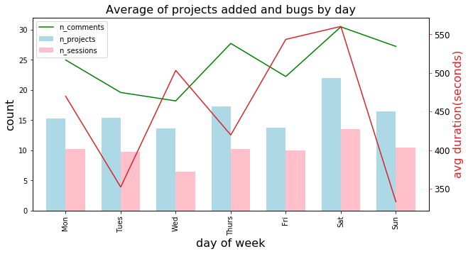

```python
import matplotlib

matplotlib.rc('figure', figsize=(10, 5))

color = 'tab:pink'

ax1 = df_day[['n_projects','n_sessions']].plot(kind='bar', color=['lightblue','pink'],  width = 0.7)


ax1 = sns.lineplot(x=df_day.index, y='n_comments', data=df_day, sort=False, color='green', label='n_comments')

ax1.set_title('Average of projects added and bugs by day', fontsize=16)
ax1.set_xlabel('day of week', fontsize=16)
ax1.set_ylabel('count', fontsize=16)
ax1.tick_params(axis='y')

ax2 = ax1.twinx()
color = 'tab:red'


ax2 = sns.lineplot(x=df_day.index, y='avg_duration', data=df_day, sort=False,color=color)
ax2.set_ylabel('avg duration(seconds)', fontsize=16, color=color)
ax2.tick_params(axis='y', color=color)




plt.yticks(fontsize=12)
plt.xticks(np.arange(7), ['Mon', 'Tues', 'Wed', 'Thurs', 'Fri', 'Sat', 'Sun'], fontsize=12)
ax1.legend(loc='upper left')


plt.show()
```

According to the plot above, the maximum average number of projects added falls on Saturdays; customers tend to add their projects on Saturday the most

The lowest number of sessions on Showwcase occured on Wednesdays. However, on average, customers spent the longest time on the platform on Saturdays, and the highest number of projects were added. Perhaps, people are more productive on Saturdays, due to the fact that it's the weekend.

People give less comments on other people's work on Wednesdays perhaps because the users tend to focus more on their own work. People give out more comments on the weekends.

## Compare bugs during a session, and amount of sessions each day of the week

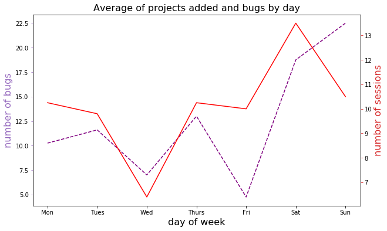

```python
fig, ax = plt.subplots(figsize=(10,6))

color = 'tab:purple'
#bar plot creation
ax.plot(df_day[['n_bugs']], '--',color='purple', label="bugs")
ax.set_xlabel('day of week', fontsize=16)
ax.set_ylabel('number of bugs', fontsize=16, color=color)
ax.set_title('Average of projects added and bugs by day', fontsize=16)
ax.tick_params(axis='y', color=color)

#specify we want to share the same x-axis
ax2 = ax.twinx()
color = 'tab:red'
#line plot creation

ax2.plot(df_day.n_sessions, color='red', label="projects")
ax2.set_ylabel('number of sessions', fontsize=16, color=color)
ax2.tick_params(axis='y', color=color)
#show plot

plt.xticks(np.arange(7), ['Mon', 'Tues', 'Wed', 'Thurs', 'Fri', 'Sat', 'Sun'])


plt.show()
```

## How often each customer logged into a session during October 2019?

```python
n_sess = df["session_id"].groupby(df.customer_id).count().reset_index(name='numbeOfsessions').sort_values(by='numbeOfsessions')
n_sess.head()
```

|  | customer_id | numbeOfsessions |
| --- | --- | --- |
| 10 | 23457.0 | 1 |
| 28 | 43096.0 | 1 |
| 30 | 43658.0 | 1 |
| 31 | 46329.0 | 1 |
| 16 | 29345.0 | 1 |

```python
n_sess['numbeOfsessions'].describe()
```

```
count    48.000000
mean      6.229167
std       6.011477
min       1.000000
25%       1.000000
50%       4.500000
75%       8.000000
max      22.000000
Name: numbeOfsessions, dtype: float64
```

Plot distribution of total number of sessions for each customer

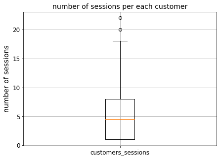

```python
fig = plt.figure(figsize =(7, 5))
ax = fig.add_subplot(111)

bp = ax.boxplot(n_sess.numbeOfsessions, labels=['customers_sessions'])

ax.set_title('number of sessions per each customer', fontsize = 14)
plt.ylabel('number of sessions', fontsize = 14)
plt.xticks(fontsize = 12)
plt.yticks(fontsize = 12)
plt.grid()
plt.show()
```

In October 2019, the majority of customers logged into the platform less than ten times.

## When did the longest session duration occur?

```python
# group by date
df_long = (df["session_duration"]).groupby(df.login_date).mean().reset_index(name='duration')
dur = df_long.pivot_table('duration', index='login_date')
max_dur = dur[dur['duration'] == max(dur.duration)]
max_dur
```

| login_date | duration |
| --- | --- |
| 2019-10-23 | 1769.75 |

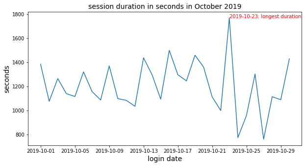

```python
fig, ax = plt.subplots(figsize=(10, 5))
ax.plot(dur)
ax.text(max_dur.index, max_dur.values, "2019-10-23: longest duration", color='red')
ax.set_title("session duration in seconds in October 2019", fontsize=14)
ax.set_ylabel("seconds", fontsize=14)
ax.set_xlabel("login date", fontsize=14)
plt.show()
```

The maximum of the average duration of the sessions for October of 2019, occured on the 10/23/2019. On 10/23/2019, customers spent the longest average duration time on the platform. The shortest duration of sessions occured towards the end of the month.

## Do customers normally add their own projects and give either likes or comments?

```python
import plotly.graph_objects as go
from plotly.subplots import make_subplots

col = ['projects_added', 'likes_given', 'comment_given' ]
TF_df = df[col]


fig = make_subplots(rows=1, cols=3, subplot_titles=('Projects Added(%)', 'Likes Given(%)', 'Comments Given(%)'))
L= len(df)

cnames = list(TF_df.columns)
for k, name in enumerate(cnames):
    n_true = (TF_df[name].sum()/L )*100
    fig.add_trace(go.Bar(x=['True', 'False'], y=[n_true, 100-n_true], name=name ), 1,k+1)
fig.update_layout(barmode='relative',  bargap=0.3, width=700, height=400)
```

[interactive chart not shown]

Regardless of the date, over 70% of the users add projects and give lkes or give comments.